# Effects of ProsperLoan Characterics on Various Features

## by Emmanuelaudu Joshua

## Investigation Overview

In this investigation, I wanted to look at the characteristics to study their relationship on borrowers's APR. The main characterics are BorrowerAPR, ProsperScore, EmploymentStatus, LoanStatus and LoanOriginalAmount

## Dataset Overview

The final dataset after preparation contains 83,982 loans with 16 features (including LoanOriginalAmount, LoanStatus, BorrowerState, BorrowerAPR, StatedMonthlyIncome, ProsperRating (Alpha), Occupation, EmploymentStatus, DebtToIncomeRatio, MonthlyLoanPayment, TotalTrades, Investors, year, month, day, time.

## Distribution of the LoanStatus

About 89% of all Prosper loans are either current or completed which we can assume that they have good profiles. Also, about 8% of Prosper's loans were charged-off or defaulted. Moreover, the remaining 2.4% of loans has the status Past Due and was grouped under a single status: Past Due.

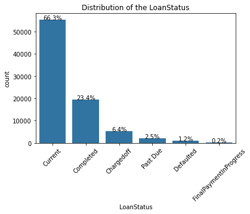

## Distribution of the BorrowerAPR

The visualization shown depicts that the BorrowerAPR is multimodal. A small peak at 0.10, and a large peak at 0.20. There is a very significant peak between 0.30 and 0.40. There are few loans after the 0.40 level.

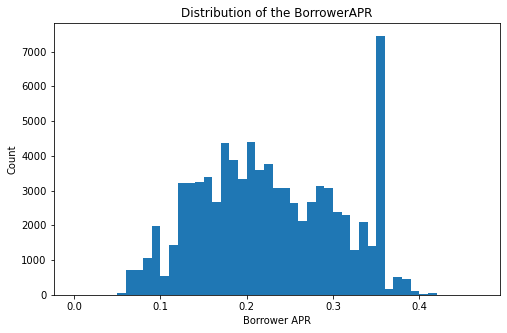

## Relationship between the Years and LoanOriginalAmount

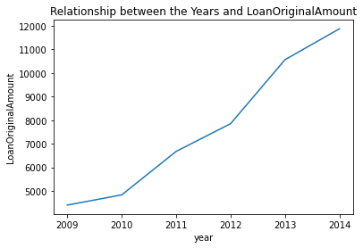

## Relationship between `Employment Status` and `months`

It can be seen that `Employed` and`Self-employed` borrowers, borrow more money in *January* but the `Full-time` borrowers are more in *July*

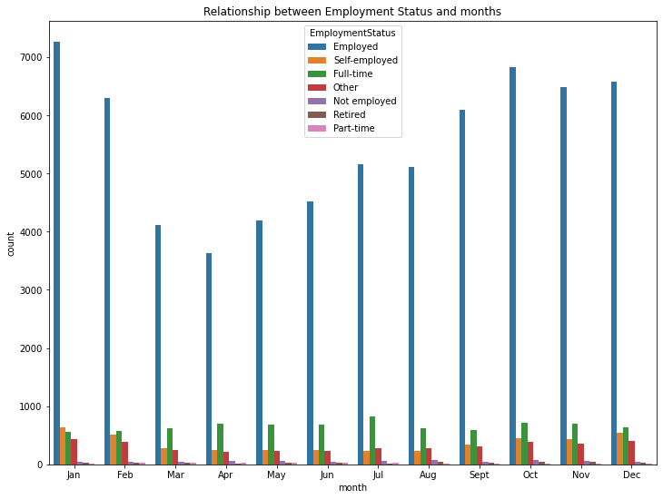

## A look on how the `ProsperRating` have effects on relationship of `BorrowerAPR` and `LoanOriginalAmount`

> - The LoanOriginalAmount increases with higher ProsperRating.
> - The BorrowerAPR decreases with higher ProsperRating.
> - The relationship between BorroweAPR and LoanOriginalAmount turns from negative to slightly positive when the ProsperRating increases from HR to A or better. This may because people with A or AA ratings tend to borrow more money, increasting APR could prevent them borrow even more and maximize the profit. But people with lower ratings tend to borrow less money, decreasing APR could encourage them to borrow more.

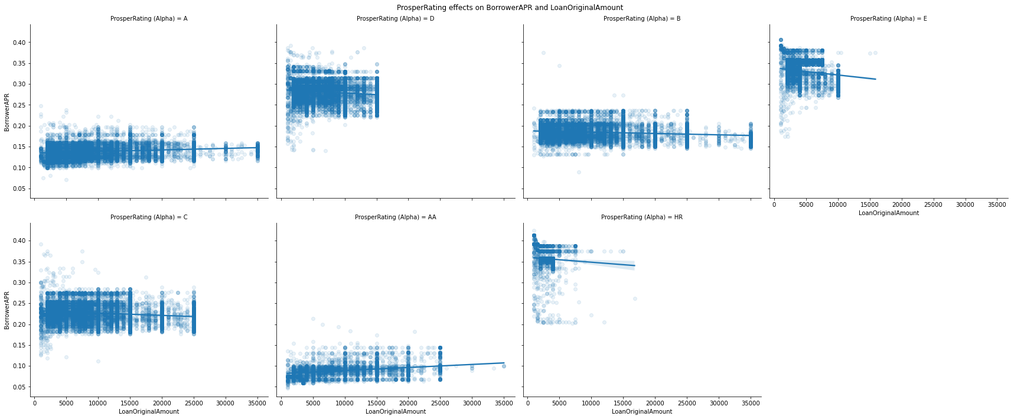